# Лекция 1: введение

## План лекции:

```
1. Что такое машинное обучение и с чем его едят.
2. Методология CRISP-DM
3. Введение в Python.
4. Примеры работы в Jupyter notebook.
5. numpy
6. matplotlib
7. Полезные ссылки
8. Домашнее задание
```

# Часть 1. Что такое машинное обучение.

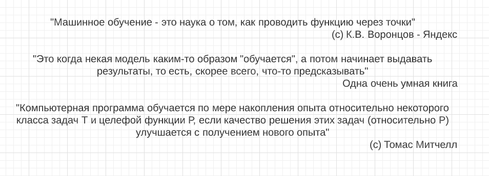

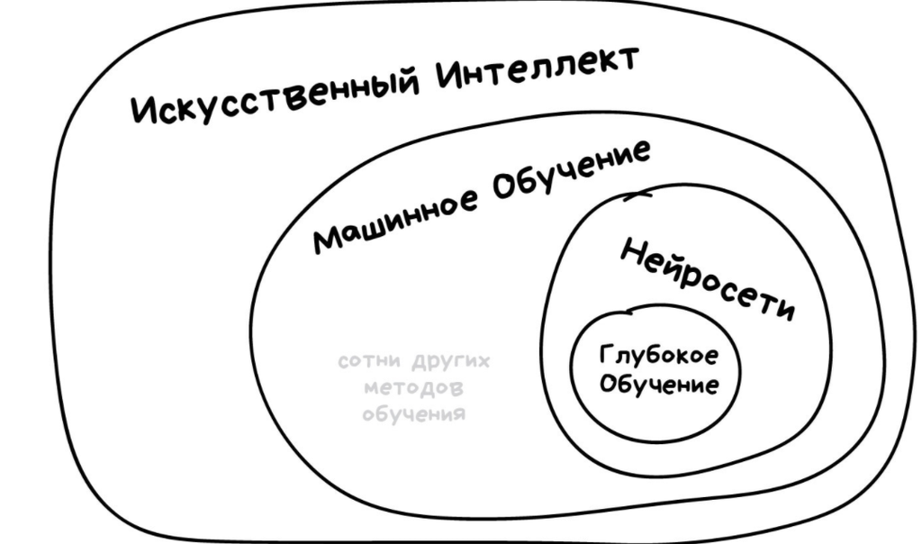

## Классификация постановок задач машинного обучения

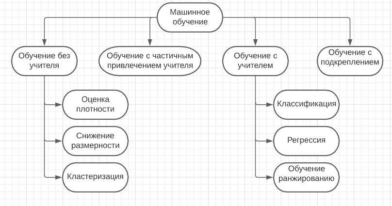

## Некоторые применения методов машинного обучения

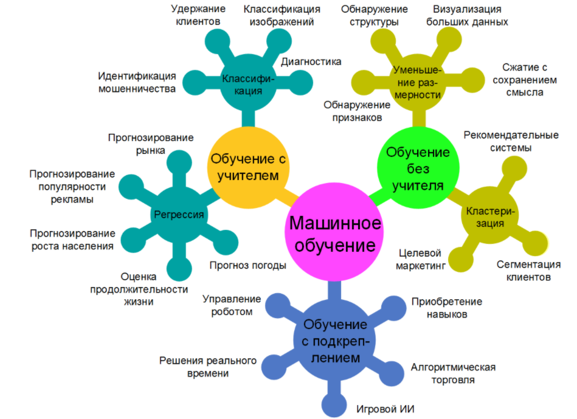

# Часть 2. Методология CRISP-DM (CRoss Industry Standard Process of Data Mining)

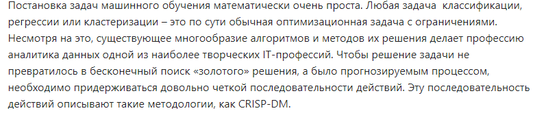

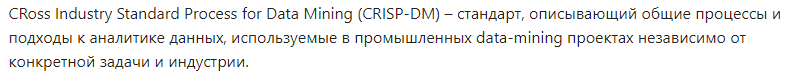

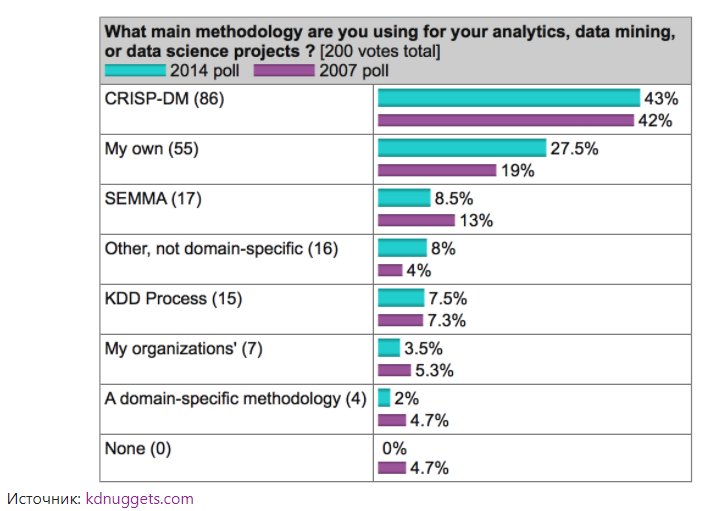

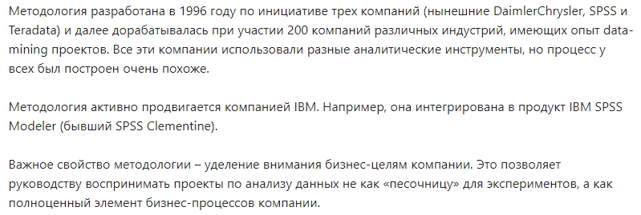

### По этой методологии DM-исследование состоит из шести стадий:

```
1. Бизнес-анализ
2. Анализ данных
3. Подготовка данных
4. Моделирование
5. Оценка решения
6. Внедрение
```

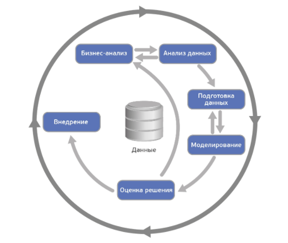

### Каждая из этих стадий в свою очередь включает в себя несколько пунктов

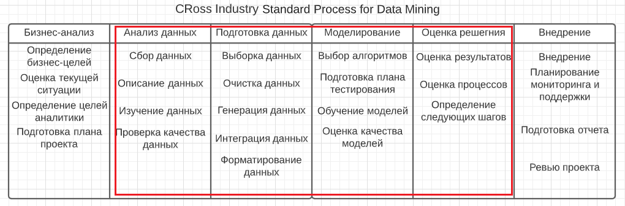

# Часть 3. Введение в python

```python
"""Подключение предустановленных библиотек и собственных модулей"""
import pandas as pd  # as pd - использование псевдонима pd
import math
import time
import random

"""Определение функции"""
def Variables():
    arr = ['a', 'b', 'c'] #список
    print(arr, 'Тип:', type(arr))

    a = 3 #переменная
    arr = arr + [a]
    arr.append(math.e) #добавление в конец массива числа e из библиотеки math
    print(*arr)
    arr.clear()
    print("Список пуст:\n", arr)

    arr = [i*2 for i in range(10)]
    print("\nСписок из десяти четных чисел:\n", arr)

    arr2 = [i for i in range(3, 15, 2)]
    print("\nСписок из чисел [3, 15) с шагом 2:")
    for item in arr2:
        print(item, end = ' ')


    """Генерация списков"""
    arr2.clear()
    print("\n\nСписок из чисел, которые делятся на 3 (генератор):")
    arr2 = (i for i in range(1, 13) if i % 3 == 0) #Круглые скобки!
    for i in arr2:
        print(i, end = ' ')
    print("\n\nПечать того же генератора: ")
    for i in arr2:
        print(i, end = ' ')

Variables() #вызов функции
```

```
['a', 'b', 'c'] Тип: <class 'list'>
a b c 3 2.718281828459045
Список пуст:
 []

Список из десяти четных чисел:
 [0, 2, 4, 6, 8, 10, 12, 14, 16, 18]

Список из чисел [3, 15) с шагом 2:
3 5 7 9 11 13

Список из чисел, которые делятся на 3 (генератор):
3 6 9 12

Печать того же генератора:
```

```python
def Dictionary():
    d1 = {'Страна': ['Франция', 'Италия', 'Великобритания'],
              'Столица': ['Париж', 'Рим', 'Лондон']}  #словарь
    print('\n', 'Тип:', type(d1))

    for key, value in d1.items():
        print(key, ':', value) #каждый проход цикла печатает 'ключ: значение' словаря

    """Использование библиотеки pandas"""
    d2 = pd.DataFrame(d1)
    print('\n', 'Использование библиотеки pandas', '\n', d2, '\n')

    """Использование библиотек random и time для создания словаря"""
    d1.clear()
    A = int(time.time()%2)
    B = int(time.time()%13)
    d1 = {key: random.randint(A,B) for key in range(5)}
    print("Словарь с использованием random: ", d1)

Dictionary()
```

```
 Тип: <class 'dict'>
Страна : ['Франция', 'Италия', 'Великобритания']
Столица : ['Париж', 'Рим', 'Лондон']

 Использование библиотеки pandas
            Страна Столица
0         Франция   Париж
1          Италия     Рим
2  Великобритания  Лондон

Словарь с использованием random:  {0: 1, 1: 0, 2: 0, 3: 1, 4: 1}
```

```python
def Cycles_and_conditions(mas):
    s = 0
    for i in range(len(mas)): #проходим все значения в массиве (списке)
        s = s + mas[i]
    print('Массив:', mas, '\n',
          'Длина массива:', len(mas), '\n',
         'Сумма всех элементов массива:', s, '\n')

    x = 2
    st = '' #строка
    if mas[1] < x < mas[2]:
        st = "It's true, " + str(mas[0]) + ' < ' + str(x) + ' < ' + str(mas[1])
    elif x > max(mas):
        st = "It's true, " + str(x) + ' > ' + str(max(mas))
    else:
        st = "Измените 'x'"
    print(st, '\n')

    i = 0
    while True: #бесконечный цикл
        if i == 3:
            break
        else:
            print(i)
            i = i + 1
    return s, x, st

mas = [1, 2, 3, 4]
print(Cycles_and_conditions(mas))
```

```
Массив: [1, 2, 3, 4]
 Длина массива: 4
 Сумма всех элементов массива: 10

Измените 'x'

0
1
2
(10, 2, "Измените 'x'")
```

```python
"""Генерация и лямбда-функции"""
def Сreate_Generator():
    mylist = range(4)
    for i in mylist :
        yield i*i #действует как return

mygenerator = Сreate_Generator() # создаём генератор
print("Ошибка:\n", mygenerator)
for i in mygenerator:
    print(i, end = ' ')
print("\nВторая печать генератора: ")
for i in mygenerator:
    print(i, end = ' ')


print("\nРезультат работы лямбда-функции:", (lambda x: x * 2)(3))

func = lambda x, y: x + y
print("\nРезультат поместили в переменную: ", func(1, 2))
```

```
Ошибка:
 <generator object Сreate_Generator at 0x000002697D7B0D60>
0 1 4 9
Вторая печать генератора:

Результат работы лямбда-функции: 6

Результат поместили в переменную:  3
```

## Еще немного питона:

### 0. Генераторы массивов и словарей.

### [ f(e) for e in iter_object]

```python
# list comprehension
[i+1 for i in range(3)]
```

```
[1, 2, 3]
```

### { key : f(e) for e in iter_object}

```python
# dict comprehension
{str(i/2):i**3 for i in range(4)}
```

```
{'0.0': 0, '0.5': 1, '1.0': 8, '1.5': 27}
```

### 1. Срезы массивов.

### mas[от(включительно) : до(не включительно) : с шагом]

По умолчанию:

- от = 0
- до = последний
- шаг = 1

```python
mas = [1,2,3,4,5,6,7,8,9]
mas
```

```
[1, 2, 3, 4, 5, 6, 7, 8, 9]
```

```python
# есть отрицательная индексация - с конца
mas[-9]
```

```
1
```

```python
print(mas[::])
print(mas[:])
print(mas)
```

```
[1, 2, 3, 4, 5, 6, 7, 8, 9]
[1, 2, 3, 4, 5, 6, 7, 8, 9]
[1, 2, 3, 4, 5, 6, 7, 8, 9]
```

```python
mas[4:]
```

```
[5, 6, 7, 8, 9]
```

```python
mas[-5:]
```

```
[5, 6, 7, 8, 9]
```

```python
mas[-5::-1]
```

```
[5, 4, 3, 2, 1]
```

```python
mas[-2:1:-2]
```

```
[8, 6, 4]
```

### 2. Строки.

```python
'одинарные кавычки'
```

```
'одинарные кавычки'
```

```python
"двойные кавычки"
```

```
'двойные кавычки'
```

```python
'''
  ТРОЙНЫЕ кавычки,
  в которых можно писать прям вот
              так...
              Но вот только выводятся они в юпитере
              не очень красиво(
'''
```

```
'\n  ТРОЙНЫЕ кавычки,\n  в которых можно писать прям вот \n              так...\n              Но вот только выводятся они в юпитере\n              не очень красиво(\n'
```

```python
'СТРОКИ' + ' МОЖНО ' + 'СОЕДИНЯТЬ'
```

```
'СТРОКИ МОЖНО СОЕДИНЯТЬ'
```

```python
bilo, syel = 10, 4
'А еще, допустим, у меня было {} яблок. Иван съел {}. И осталось {} штук.'.format(bilo, syel, bilo-syel)
```

```
'А еще, допустим, у меня было 10 яблок. Иван съел 4. И осталось 6 штук.'
```

# Часть 4. Примеры работы в jupyter notebook

### jupyter notebook - это мощный интерактивный инструмент для исследований, который может совмещать текст, код, картинки, графики и таблицы.

### Данный ноутбук можно выгрузить в виде html документа, pdf и многих других:

### file -> Download as -> html...

Разные типы разметки ячеек: **command mode**(синий)/**Edit**(зеленый)**mode**

### command mode

Чтобы Включить command mode, необходимо Выбрать ячейку и нажать на Esc.

```
В этом режиме Вам доступны команды по форматированию ноутбука на уровне ячеек:
    1. 'A' - создать ячейку над текущей ячейкой
    2. 'B' - создать ячейку под текущей ячейкой
    3. 'X' - удалить ячейку
    4. 'M' - перевести ячейку в формат "markdown" - это текст на белом фоне
    5. 'Y' - перевести ячейку в формат "Code" - исполняемая ячейка с кодом
    6. 'F' - поиск и замена
    7. shift + M - объединить текущую ячейку со следующей
    8. Больше команд можно увидеть так: Help -> Keyboard shortcuts
```

### edit mode

В этом режиме можно форматировать ячейки на уровне содержимого. Для перехода в режим 'edit' из режима 'command' нужно либо кликнуть по ячейки, либо нажать 'enter'.

```
        * tab - автозаполнение кода или отступ
        * shift + tab - показывает подсказку
```

### Ячейки можно исполнять, находясь в любом режиме разметки.

```
Различные способы исполнить ячейку:
    1. ctrl + enter - выполнение ячейки, причем выбрана остается текущая ячейка
    2. shift + enter - выполнение ячейки, но выбранной становится следующая
    3. alt + enter - выполнение ячейки, создание ячейки после текущей и переход в неё
```

### Что еще можно делать в ячейке типа markdown:

Вставлять формулы с помощью синтаксиса LaTeX $$e^{i\pi} + 1 = 0$$

И даже вот такие $$e^x=\sum_{i=0}^\infty \frac{1}{i!}x^i$$

$$Это тоже LaTeX$$

Выделять куски текста **жирным шрифтом**

*или курсивом*

| можно | даже |
| --- | --- |
| рисовать | таблицы |

#### Можно создавать списки:

- первый пункт
- второй пункт
  - третий пункт
    - четвертый пункт
    - пятый **пункт**
- и так *далее*

# И делать

## Заголовки

### Разной

#### Толщины

# Часть 5. numpy

```python
import numpy as np
```

```python
np.__version__
```

```
'1.18.5'
```

##### numpy - библиотека для векторизованных вычислений. Написана на С

##### scipy - библиотека для научных вычислений. Написана на С, С++, Fortran

### Что даёт numpy? скорость + удобство

```python
a = list(range(1_000_000)) #на чистом питоне возведем список поэлементно в квадрат
```

```python
%%timeit
[e*e for e in a]
```

```
151 ms ± 4.74 ms per loop (mean ± std. dev. of 7 runs, 10 loops each)
```

```python
a = np.arange(1000000) #а теперь сделаем то же самое, но с использованием numpy
```

```python
%%timeit
a*a
```

```
2.48 ms ± 90.1 µs per loop (mean ± std. dev. of 7 runs, 100 loops each)
```

### Как хранятся массивы numpy

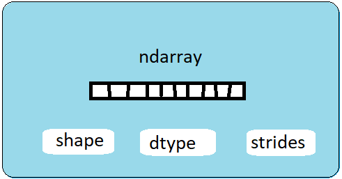

###### numpy массивы хранятся в памяти, как единый большой кусок данных.

###### при изменении атрибута shape меняются только указатели на то, где начинается новая строка, столбец и так далее.

```python
a = np.array([1,2,3,4,5,6], dtype = np.float)
```

```python
type(a)
```

```
numpy.ndarray
```

```python
a.dtype #тип данных, хранящихся в массиве
```

```
dtype('float64')
```

```python
a.shape # количество элементов по каждой размерности
```

```
(6,)
```

```python
a.ndim #количество размерностей
```

```
1
```

```python
a.astype(str) # меняем тип элементов массива
```

```
array(['1.0', '2.0', '3.0', '4.0', '5.0', '6.0'], dtype='<U32')
```

```python
a = np.zeros((3,4),dtype = float)
a
```

```
array([[0., 0., 0., 0.],
       [0., 0., 0., 0.],
       [0., 0., 0., 0.]])
```

```python
a.strides # показывает,на какое количество байт нужно отойти, чтобы перейти на следующий элемент по каждой из размерностей
```

```
(32, 8)
```

```python
a.dtype.itemsize
```

```
8
```

### Быстрая генерация массивов:

```python
# прямой способ
np.array([1,2,3,4,5,6], dtype = np.float)
```

```
array([1., 2., 3., 4., 5., 6.])
```

```python
# создать n-мерный массив, заполненый нулями (в данном случае - двумерный массив)
np.zeros(shape = [2,10])
```

```
array([[0., 0., 0., 0., 0., 0., 0., 0., 0., 0.],
       [0., 0., 0., 0., 0., 0., 0., 0., 0., 0.]])
```

```python
# создать n-мерный массив, заполненный единицами (одномерный)
np.ones(3)
```

```
array([1., 1., 1.])
```

```python
# создать n-мерный массив, заполненный чем угодно (трехмерный)
np.full([2,2,2],9)
```

```
array([[[9, 9],
        [9, 9]],

       [[9, 9],
        [9, 9]]])
```

```python
# создает вектор, заполненный числами из диапазона [start,stop) с шагом
np.arange(start = 0, stop = 1, step = 0.1)
```

```
array([0. , 0.1, 0.2, 0.3, 0.4, 0.5, 0.6, 0.7, 0.8, 0.9])
```

```python
# разбивает диапазон [start,stop] на сетку из num элементов
np.linspace(start = 0, stop = 1, num=20, endpoint = True)
```

```
array([0.        , 0.05263158, 0.10526316, 0.15789474, 0.21052632,
       0.26315789, 0.31578947, 0.36842105, 0.42105263, 0.47368421,
       0.52631579, 0.57894737, 0.63157895, 0.68421053, 0.73684211,
       0.78947368, 0.84210526, 0.89473684, 0.94736842, 1.        ])
```

```python
# создает матрицу с заданными диагональными элементами
# эти заданные элементы можно расположить, как на диагонали, так и под или над ней, изменяя параметр k
np.diag(np.arange(1,5), k=-1)
```

```
array([[0, 0, 0, 0, 0],
       [1, 0, 0, 0, 0],
       [0, 2, 0, 0, 0],
       [0, 0, 3, 0, 0],
       [0, 0, 0, 4, 0]])
```

```python
# создание единичной матрицы заданной величины
np.eye(4)
```

```
array([[1., 0., 0., 0.],
       [0., 1., 0., 0.],
       [0., 0., 1., 0.],
       [0., 0., 0., 1.]])
```

### Некоторые полезные функции:

```python
a = np.arange(12)
a
```

```
array([ 0,  1,  2,  3,  4,  5,  6,  7,  8,  9, 10, 11])
```

```python
# меняет размерность массива
b = a.reshape(3,4)
b
```

```
array([[ 0,  1,  2,  3],
       [ 4,  5,  6,  7],
       [ 8,  9, 10, 11]])
```

```python
# вытягивает массив в вектор
b.flatten(order = 'C') # copy
```

```
array([ 0,  1,  2,  3,  4,  5,  6,  7,  8,  9, 10, 11])
```

```python
b.flatten(order = 'F')
```

```
array([ 0,  4,  8,  1,  5,  9,  2,  6, 10,  3,  7, 11])
```

```python
# вытягивает массив в вектор - возвращает ссылку на исходный массив
c = a.ravel()
```

```python
c
```

```
array([ 0,  1,  2,  3,  4,  5,  6,  7,  8,  9, 10, 11])
```

```python
a
```

```
array([ 0,  1,  2,  3,  4,  5,  6,  7,  8,  9, 10, 11])
```

```python
c[0] = 90
```

```python
a
```

```
array([90,  1,  2,  3,  4,  5,  6,  7,  8,  9, 10, 11])
```

```python
# добавление размерностей
d = a[:,np.newaxis] # эквивалентно a.reshape(*a.shape,1)
d
```

```
array([[90],
       [ 1],
       [ 2],
       [ 3],
       [ 4],
       [ 5],
       [ 6],
       [ 7],
       [ 8],
       [ 9],
       [10],
       [11]])
```

```python
d.shape
```

```
(12, 1)
```

```python
d[np.newaxis,:].shape # эквивалентно a.reshape(1,*a.shape)
```

```
(1, 12, 1)
```

```python
# транспонирование массива
d.T # можно d.transpose()
```

```
array([[90,  1,  2,  3,  4,  5,  6,  7,  8,  9, 10, 11]])
```

```python
# создание копий
np.asarray(a)
```

```
array([90,  1,  2,  3,  4,  5,  6,  7,  8,  9, 10, 11])
```

```python
a.reshape(3,4)
```

```
array([[90,  1,  2,  3],
       [ 4,  5,  6,  7],
       [ 8,  9, 10, 11]])
```

### Зачем все это надо?

### ЧТОБЫ ДЕЛАТЬ ВОТ ТАК!

```python
a = np.random.randint(0,10,(5,5))
t = np.linspace(1,25,25).reshape(5,5)
foo = lambda x,y: (x-y)**3
a
```

```
array([[3, 1, 2, 4, 6],
       [5, 3, 8, 0, 4],
       [2, 5, 0, 6, 9],
       [5, 8, 2, 9, 8],
       [6, 9, 6, 3, 5]])
```

```python
t
```

```
array([[ 1.,  2.,  3.,  4.,  5.],
       [ 6.,  7.,  8.,  9., 10.],
       [11., 12., 13., 14., 15.],
       [16., 17., 18., 19., 20.],
       [21., 22., 23., 24., 25.]])
```

```python
f = a*t**2 - 5/t**a + np.sin(t)*np.exp(1/t) * foo(a,t)
```

```python
f
```

```
array([[ 1.62988423e+01,  8.21991000e-04,  1.72474956e+01,
         6.39804688e+01,  1.48828447e+02],
       [ 1.80329447e+02,  9.84813112e+01,  5.12000000e+02,
        -3.40741144e+02,  5.29866543e+02],
       [ 1.04032938e+03,  9.20038704e+02, -1.00191769e+03,
         6.31255888e+02,  1.87485449e+03],
       [ 1.68791354e+03,  3.05532245e+03,  3.89975577e+03,
         3.09102324e+03,  1.54154689e+03],
       [-3.15428210e+02,  4.37635065e+03,  7.51622802e+03,
         1.04713831e+04,  4.22702502e+03]])
```

```python
mask = (f<0) | (f>100)
mask
```

```
array([[False, False, False, False,  True],
       [ True, False,  True,  True,  True],
       [ True,  True,  True,  True,  True],
       [ True,  True,  True,  True,  True],
       [ True,  True,  True,  True,  True]])
```

```python
f[(f<0) | (f>100)]
```

```
array([  148.82844725,   180.3294474 ,   511.9999997 ,  -340.7411438 ,
         529.86654308,  1040.32938048,   920.03870407, -1001.91769039,
         631.25588844,  1874.8544899 ,  1687.91354216,  3055.32244602,
        3899.75577363,  3091.02323969,  1541.54689434,  -315.42820992,
        4376.3506475 ,  7516.22802314, 10471.38307355,  4227.02501937])
```

```python
hundred = np.where((f<100) & (f>0))
hundred
```

```
(array([0, 0, 0, 0, 1], dtype=int64), array([0, 1, 2, 3, 1], dtype=int64))
```

```python
f[hundred]
```

```
array([1.62988423e+01, 8.21991000e-04, 1.72474956e+01, 6.39804688e+01,
       9.84813112e+01])
```

```python
(f<100) & (f>0)
```

```
array([[ True,  True,  True,  True, False],
       [False,  True, False, False, False],
       [False, False, False, False, False],
       [False, False, False, False, False],
       [False, False, False, False, False]])
```

### Какие типы индексации поддерживает numpy:

- по номеру элемента
- логическая

### а) По номеру элемента:

```python
a = np.random.randint(0,10,(12))
a = a.reshape(3,4)
a
```

```
array([[0, 2, 4, 3],
       [6, 3, 5, 1],
       [2, 7, 3, 9]])
```

```python
# можно обратиться прямо к строке
a[2] #на самом деле - ко второму элементу в нулевой оси
```

```
array([2, 7, 3, 9])
```

```python
a[:,1]
```

```
array([2, 3, 7])
```

```python
random_array = np.random.randint(0,10,(2,4,4))
random_array
```

```
array([[[8, 7, 8, 2],
        [3, 2, 0, 0],
        [6, 1, 1, 6],
        [0, 8, 3, 1]],

       [[4, 7, 0, 1],
        [0, 6, 4, 5],
        [3, 9, 4, 7],
        [1, 4, 8, 8]]])
```

**Здесь, как и в чистом питоне, работают срезы, но по каждой оси нужно задаватьс вой срез**

```python
random_array[0,:,0]
```

```
array([8, 3, 6, 0])
```

```python
random_array[...,0]
```

```
array([[8, 3, 6, 0],
       [4, 0, 3, 1]])
```

```python
random_array[1,...]
```

```
array([[4, 7, 0, 1],
       [0, 6, 4, 5],
       [3, 9, 4, 7],
       [1, 4, 8, 8]])
```

```python
srezz = random_array[:,2:-1,-2::1]
srezz
```

```
array([[[1, 6]],

       [[4, 7]]])
```

```python
random_array.shape, srezz.shape # размеры среза всегда меньше размеров исходного массива
```

```
((2, 4, 4), (2, 1, 2))
```

### б) Логическая индексация.

```python
g = np.random.randint(-100,100,(5,5))
```

```python
g
```

```
array([[-94, -39, -60, -55, -10],
       [ 15,  59, -13,  41,  87],
       [-72, -67, -63, -51,  58],
       [ 15, -94,  57,  35,  40],
       [ 66,  84, -24,  35, -63]])
```

```python
mask = (g > -50) & (g < 50)
```

```python
mask
```

```
array([[False,  True, False, False,  True],
       [ True, False,  True,  True, False],
       [False, False, False, False, False],
       [ True, False, False,  True,  True],
       [False, False,  True,  True, False]])
```

```python
g[mask]
```

```
array([-39, -10,  15, -13,  41,  15,  35,  40, -24,  35])
```

```python
g[(g-20) < 0]
```

```
array([-94, -39, -60, -55, -10,  15, -13, -72, -67, -63, -51,  15, -94,
       -24, -63])
```

### Агрегирующие операции

np.max(a), np.min(a), np.argmax(a), np.argmin(a), np.mean(a), np.std(a), np.prod(a), np.sum(a)

**Агрегирующие операции выполняются ВДОЛЬ осей!**

Общий синтаксис: **np.agrfunc(mas, axis = (axisN1,axisN2,...))**

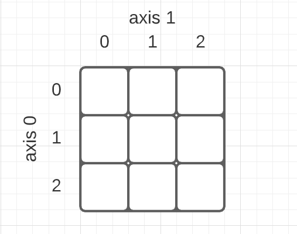

```python
# задаем начальное значение генератора случайных чисел
np.random.seed(2020)
a = np.random.randint(0,100,(6,6))
a
```

```
array([[96,  8, 67, 67, 91,  3],
       [71, 56, 29, 48, 32, 24],
       [74,  9, 51, 11, 55, 62],
       [67, 69, 48, 28, 20,  8],
       [38, 84, 65,  1, 79, 69],
       [74, 73, 62, 21, 29, 90]])
```

```python
np.max(a,axis = 0) # вдоль оси 0 (получаем строку)
```

```
array([96, 84, 67, 67, 91, 90])
```

```python
np.min(a,axis = 1) # вдоль оси 1 (получаем столбец)
```

```
array([ 3, 24,  9,  8,  1, 21])
```

```python
np.mean(a) # среднее арифметичекое по всему массиву
```

```
49.416666666666664
```

```python
b = np.random.randint(0,100,(4,2,10))
b
```

```
array([[[79, 45, 17,  7, 59, 78, 82, 89, 54, 29],
        [ 7, 51, 43, 47, 46, 98, 10, 64, 25,  6]],

       [[89, 16,  9, 96,  4, 46, 16, 77, 49, 89],
        [84, 59, 53, 94, 17, 95, 90, 96, 63, 32]],

       [[54,  8, 82, 79, 33, 40, 44,  1, 98, 71],
        [19, 13, 49, 11, 72, 89, 62, 54,  6, 13]],

       [[98, 12, 41, 37, 54, 38, 19, 40, 39, 78],
        [93, 76, 87, 13,  0,  3, 36, 20, 86, 97]]])
```

```python
np.min(b, axis = (0))
```

```
array([[54,  8,  9,  7,  4, 38, 16,  1, 39, 29],
       [ 7, 13, 43, 11,  0,  3, 10, 20,  6,  6]])
```

```python
np.min(b, axis = (0,1))
```

```
array([ 7,  8,  9,  7,  0,  3, 10,  1,  6,  6])
```

```python
np.min(b, axis = (0,2))
```

```
array([1, 0])
```

```python
np.min(b, axis = (0)).shape
```

```
(2, 10)
```

**np.argmax/argmin** - возвращает индекс элемента в развернутом массиве

Как найти **argmin** в неразвернутом массиве?

```python
a
```

```
array([[96,  8, 67, 67, 91,  3],
       [71, 56, 29, 48, 32, 24],
       [74,  9, 51, 11, 55, 62],
       [67, 69, 48, 28, 20,  8],
       [38, 84, 65,  1, 79, 69],
       [74, 73, 62, 21, 29, 90]])
```

```python
# способ первый - правильный, но не красивый
num = np.argmin(a)
i, j = num//a.shape[1], num%a.shape[1]
print('index = {}'.format((i,j)))
print('value = ',a[i,j])
```

```
index = (4, 3)
value =  1
```

```python
# способ второй - правильный и красивый
i,j = np.unravel_index(np.argmin(a),a.shape)
i,j
```

```
(4, 3)
```

### Унарные операции над булевыми массивами

- **np.any(mask)** - возвращает True, если в булевом массиве mask есть хотя бы один True
- **np.all(mask)** - возвращает True, если в mask все элементы это True
- **np.logical_not(mask)** - поэлементное логическое отрицание

```python
a = np.random.randint(-100,100,(4,4))
a
```

```
array([[-22,  96, -41,  64],
       [-86,   4,  23,  32],
       [-89, -31,   3,  54],
       [ 70, -63,  47, -35]])
```

```python
mask = (a<0)
mask
```

```
array([[ True, False,  True, False],
       [ True, False, False, False],
       [ True,  True, False, False],
       [False,  True, False,  True]])
```

```python
np.all(mask)
```

```
False
```

```python
np.any(mask)
```

```
True
```

**Можно так же использовать вдоль осей:** Тогда возвращается массив

```python
np.all(mask,axis = 0)
```

```
array([False, False, False, False])
```

```python
# Логическое отрицание
np.logical_not(mask)
```

```
array([[False,  True, False,  True],
       [False,  True,  True,  True],
       [False, False,  True,  True],
       [ True, False,  True, False]])
```

```python
~mask #короткая запись логического отрицания
```

```
array([[False,  True, False,  True],
       [False,  True,  True,  True],
       [False, False,  True,  True],
       [ True, False,  True, False]])
```

### Бинарные операции над массивами:

```python
# Далее вместо 'a' и 'b' могут стоять любые обычные числа или массивы numpy
a = np.random.randint(10,50,(4,6))
b = np.random.randint(30,50,(4,6))
a
```

```
array([[29, 30, 34, 46, 36, 41],
       [48, 22, 11, 34, 24, 21],
       [25, 36, 23, 38, 18, 10],
       [19, 28, 15, 35, 49, 46]])
```

```python
b
```

```
array([[39, 48, 40, 48, 34, 35],
       [38, 49, 44, 34, 45, 38],
       [46, 45, 39, 33, 31, 39],
       [35, 41, 44, 30, 46, 38]])
```

```python
a+b #сложение
```

[output not shown]

```python
a-b #вычитание
```

[output not shown]

```python
a*b #умножение
```

[output not shown]

```python
a**b #возвеение в степень
```

[output not shown]

```python
a/b #деление
```

[output not shown]

```python
a//b #целочисленное деление
```

[output not shown]

```python
a%b #остаток от деления
```

[output not shown]

```python
a>b
```

[output not shown]

```python
a<b
```

[output not shown]

```python
a==b
```

[output not shown]

```python
a>=b
```

[output not shown]

```python
a!=b
```

[output not shown]

**Битовые операции (имеют смысл над булевыми массивами)**

```python
mask1, mask2 = (a>20), (b<30)
```

```python
mask1 & mask2 # np.logical_and()
```

```
array([[False, False, False, False, False, False],
       [False, False, False, False, False, False],
       [False, False, False, False, False, False],
       [False, False, False, False, False, False]])
```

```python
mask1 | mask2 # np.logical_or()
```

```
array([[ True,  True,  True,  True,  True,  True],
       [ True,  True, False,  True,  True,  True],
       [ True,  True,  True,  True, False, False],
       [False,  True, False,  True,  True,  True]])
```

```python
mask1 ^ mask2 # np.logical_xor() исключающее "или"
```

```
array([[ True,  True,  True,  True,  True,  True],
       [ True,  True, False,  True,  True,  True],
       [ True,  True,  True,  True, False, False],
       [False,  True, False,  True,  True,  True]])
```

**np.fmax(a,b), np.fmin(a,b)**

```python
# сравнивает соответствующие элементы из двух массивов и выбирает из них максимальны
np.fmax(a,b)
```

```
array([[39, 48, 40, 48, 36, 41],
       [48, 49, 44, 34, 45, 38],
       [46, 45, 39, 38, 31, 39],
       [35, 41, 44, 35, 49, 46]])
```

```python
# так же, только выбирает минимальный элемент
np.fmin(a,b)
```

```
array([[29, 30, 34, 46, 34, 35],
       [38, 22, 11, 34, 24, 21],
       [25, 36, 23, 33, 18, 10],
       [19, 28, 15, 30, 46, 38]])
```

```python
# поэлементно сравнивает два массива с некоторой точностью
np.isclose(a,b)
```

```
array([[False, False, False, False, False, False],
       [False, False, False,  True, False, False],
       [False, False, False, False, False, False],
       [False, False, False, False, False, False]])
```

```python
np.allclose(a,b) # np.all(np.isclose(a,b))
```

```
False
```

**Объединение массивов**

```python
a = np.random.randint(0,10,(2,4))
a
```

```
array([[8, 3, 7, 4],
       [5, 3, 8, 2]])
```

```python
b = -a
```

```python
b
```

```
array([[-8, -3, -7, -4],
       [-5, -3, -8, -2]])
```

```python
np.append(a,b)
```

```
array([ 8,  3,  7,  4,  5,  3,  8,  2, -8, -3, -7, -4, -5, -3, -8, -2])
```

```python
np.append(a,b,axis = 0)
```

```
array([[ 8,  3,  7,  4],
       [ 5,  3,  8,  2],
       [-8, -3, -7, -4],
       [-5, -3, -8, -2]])
```

```python
np.append(a,b,axis = 1)
```

```
array([[ 8,  3,  7,  4, -8, -3, -7, -4],
       [ 5,  3,  8,  2, -5, -3, -8, -2]])
```

**Алгебраические операции над массивами**

```python
a
```

```
array([[8, 3, 7, 4],
       [5, 3, 8, 2]])
```

```python
b
```

```
array([[-8, -3, -7, -4],
       [-5, -3, -8, -2]])
```

```python
a*b #поэлементное умножение
```

```
array([[-64,  -9, -49, -16],
       [-25,  -9, -64,  -4]])
```

```python
#матричное умножение - должны соблюдаться правила умножения:
#                        n*k @ k*m = n*m
a@b.T
```

```
array([[-138, -113],
       [-113, -102]])
```

```python
v = a[0,:]
v
```

```
array([8, 3, 7, 4])
```

```python
a@v
```

```
array([138, 113])
```

```python
v1 = v[:,np.newaxis]
v1
```

```
array([[8],
       [3],
       [7],
       [4]])
```

```python
a@v1
```

```
array([[138],
       [113]])
```

```python
A = np.random.randint(0,100,(6,6))
A
```

```
array([[90, 69, 19, 24, 63, 81],
       [77, 79, 63, 72, 14,  3],
       [61, 51, 18, 43, 79,  1],
       [ 3, 80, 26, 41, 97, 78],
       [58, 42, 32, 36, 70, 98],
       [36,  5, 92, 27, 48, 92]])
```

```python
# определитель матрицы
np.linalg.det(A)
```

```
-126402035427.99982
```

```python
# норма матрицы
np.linalg.norm(A)
```

```
357.89104487259806
```

**больше методов линейной алгебры в модуле np.linalg**